# Example 1: Preprocessing Workflow

This is meant as a very simple example for a preprocessing workflow. In this workflow we will conduct the following steps:

1. Motion Correction of functional images with FSL's MCFLIRT
2. Image Resampling of anatomical image to a resolution of 3mmx3mmx3mm voxel size with AFNI's 3dresample
3. Image Correction of motion corrected functional images to the resampled anatomical image with FSL's FLIRT
4. Smoothing of coregistrated functional images with FWHM set to 4mm and 8mm

```python
!nib-ls /data/ds000114/sub-01/*/*.nii.gz
```

```
/data/ds000114/sub-01/anat/sub-01_T1w.nii.gz                      float32 [256, 156, 256]      1.00x1.30x1.00         sform
/data/ds000114/sub-01/dwi/sub-01_dwi.nii.gz                        int16  [128, 128,  72,  71] 2.00x2.00x2.00x16.50
/data/ds000114/sub-01/func/sub-01_task-fingerfootlips_bold.nii.gz  int16  [ 64,  64,  30, 184] 4.00x4.00x4.00x2.50    sform
/data/ds000114/sub-01/func/sub-01_task-linebisection_bold.nii.gz   int16  [ 64,  64,  30, 238] 4.00x4.00x4.00x2.50    sform
```

**So, let's start!**

# Imports

First, let's import all modules we later will be needing.

```python
%pylab inline
from os.path import join as opj
from nipype.interfaces.fsl import MCFLIRT, FLIRT
from nipype.interfaces.afni import Resample
from nipype.interfaces.spm import Smooth
from nipype.interfaces.utility import IdentityInterface
from nipype.interfaces.io import SelectFiles, DataSink
from nipype.pipeline.engine import Workflow, Node
```

# Experiment parameters

It's always a good idea to specify all parameters that might change between experiments at the beginning of your script.

```python
experiment_dir = '/data/output'
output_dir = 'datasink'
working_dir = 'workingdir'

# list of subject identifiers
subject_list = ['sub-01', 'sub-02']

# list of session identifiers
task_list = ['fingerfootlips', 'linebisection']

# Smoothing widths to apply
fwhm = [4, 8]
```

# Specify Nodes

Initiate all the different interfaces (represented as nodes) that you want to use in your workflow.

```python
# MCFLIRT - motion correction
mcflirt = Node(MCFLIRT(mean_vol=True,
                       save_plots=True,
                       output_type='NIFTI'),
               name="mcflirt")

# Resample - resample anatomy to 3x3x3 voxel resolution
resample = Node(Resample(voxel_size=(3, 3, 3),
                         outputtype='NIFTI'),
                name="resample")

# FLIRT - coregister functional images to anatomical images
coreg_step1 = Node(FLIRT(output_type='NIFTI'), name="coreg_step1")
coreg_step2 = Node(FLIRT(output_type='NIFTI',
                         apply_xfm=True), name="coreg_step2")

# Smooth - image smoothing
smooth = Node(Smooth(), name="smooth")
smooth.iterables = ("fwhm", fwhm)
```

# Specify input & output stream

Specify where the input data can be found & where and how to save the output data.

```python
# Infosource - a function free node to iterate over the list of subject names
infosource = Node(IdentityInterface(fields=['subject_id', 'task_name']),
                  name="infosource")
infosource.iterables = [('subject_id', subject_list),
                        ('task_name', task_list)]

# SelectFiles - to grab the data (alternativ to DataGrabber)
anat_file = opj('{subject_id}', 'anat', '{subject_id}_T1w.nii.gz')
func_file = opj('{subject_id}', 'func',
                '{subject_id}_task-{task_name}_bold.nii.gz')

templates = {'anat': anat_file,
             'func': func_file}
selectfiles = Node(SelectFiles(templates,
                               base_directory='/data/ds000114'),
                   name="selectfiles")

# Datasink - creates output folder for important outputs
datasink = Node(DataSink(base_directory=experiment_dir,
                         container=output_dir),
                name="datasink")

# Use the following DataSink output substitutions
substitutions = [('_subject_id', ''),
                 ('_mcf.nii_mean_reg', '_mean'),
                 ('.nii.par', '.par'),
                 ]
subjFolders = [('%s_%s/' % (task, sub), '%s/%s' % (sub, task))
               for task in task_list
               for sub in subject_list]
subjFolders += [('%s_%s' % (sub, task), '')
                for task in task_list
                for sub in subject_list]
subjFolders += [('%s%s_' % (task, sub), '')
                for task in task_list
                for sub in subject_list]
substitutions.extend(subjFolders)
datasink.inputs.substitutions = substitutions
```

# Specify Workflow

Create a workflow and connect the interface nodes and the I/O stream to each other.

```python
# Create a preprocessing workflow
preproc = Workflow(name='preproc')
preproc.base_dir = opj(experiment_dir, working_dir)

# Connect all components of the preprocessing workflow
preproc.connect([(infosource, selectfiles, [('subject_id', 'subject_id'),
                                            ('task_name', 'task_name')]),
                 (selectfiles, mcflirt, [('func', 'in_file')]),
                 (selectfiles, resample, [('anat', 'in_file')]),

                 (mcflirt, coreg_step1, [('mean_img', 'in_file')]),
                 (resample, coreg_step1, [('out_file', 'reference')]),

                 (mcflirt, coreg_step2, [('out_file', 'in_file')]),
                 (resample, coreg_step2, [('out_file', 'reference')]),
                 (coreg_step1, coreg_step2, [('out_matrix_file',
                                              'in_matrix_file')]),

                 (coreg_step2, smooth, [('out_file', 'in_files')]),

                 (mcflirt, datasink, [('par_file', 'preproc.@par')]),
                 (resample, datasink, [('out_file', 'preproc.@resample')]),
                 (coreg_step1, datasink, [('out_file', 'preproc.@coregmean')]),
                 (smooth, datasink, [('smoothed_files', 'preproc.@smooth')]),
                 ])
```

# Visualize the workflow

It always helps to visualize your workflow.

```
170720-11:32:53,522 workflow INFO:
	 Generated workflow graph: /data/output/workingdir/preproc/graph.dot.png (graph2use=colored, simple_form=True).
```

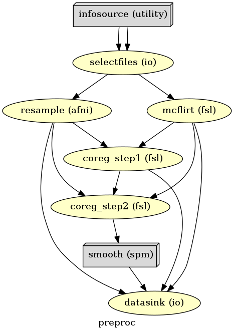

```python
# Create preproc output graph
preproc.write_graph(graph2use='colored', format='png', simple_form=True)

# Visualize the graph
from IPython.display import Image
Image(filename=opj(preproc.base_dir, 'preproc', 'graph.dot.png'))
```

```
170720-11:32:55,581 workflow INFO:
	 Generated workflow graph: /data/output/workingdir/preproc/graph.dot.png (graph2use=flat, simple_form=True).
```

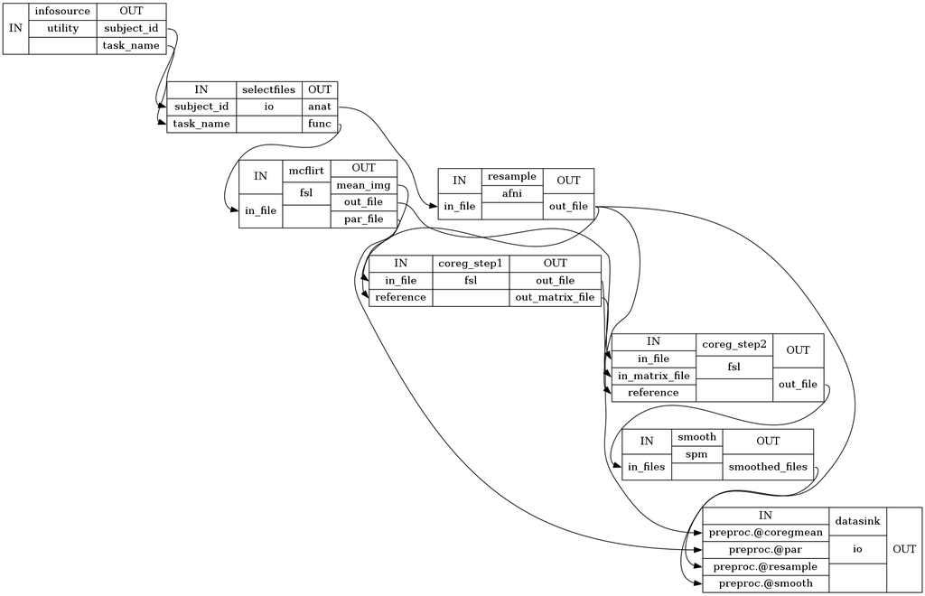

```python
# Visualize the detailed graph
preproc.write_graph(graph2use='flat', format='png', simple_form=True)
Image(filename=opj(preproc.base_dir, 'preproc', 'graph_detailed.dot.png'))
```

# Run the Workflow

Now that everything is ready, we can run the preprocessing workflow. Change `n_procs` to the number of jobs/cores you want to use.

```python
preproc.run('MultiProc', plugin_args={'n_procs': 4})
```

[output not shown]

[output cut: 191 more lines]

[output not shown]

[output not shown]

# Inspect output

let's check the structure of the output folder, to see if we have everything we wanted to save.

```python
!tree /output/datasink/preproc/sub-01/
```

[output not shown]

# Visualize results

let's check the effect of the different smoothing kernels.

```
<nilearn.plotting.displays.OrthoSlicer at 0x7fbebc997210>
```

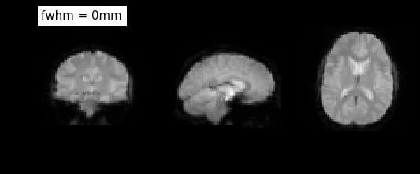

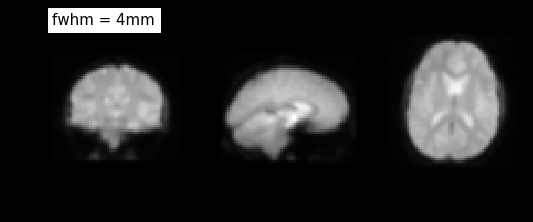

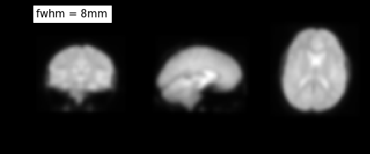

```python
preproc.run('MultiProc', plugin_args={'n_procs': 4})
from nilearn import image, plotting
plotting.plot_epi(
    '/output/datasink/preproc/sub-01/run-1_bold_mean_flirt.nii', title="fwhm = 0mm",
    display_mode='ortho', annotate=False, draw_cross=False, cmap='gray')

mean_img = image.mean_img('/output/datasink/preproc/sub-01/run-1_fwhm_4/s_bold_mcf_flirt.nii')
plotting.plot_epi(mean_img, title="fwhm = 4mm", display_mode='ortho',
                  annotate=False, draw_cross=False, cmap='gray')

mean_img = image.mean_img('/output/datasink/preproc/sub-01/run-1_fwhm_8/s_bold_mcf_flirt.nii')
plotting.plot_epi(mean_img, title="fwhm = 8mm", display_mode='ortho',
                  annotate=False, draw_cross=False, cmap='gray')
```

How do the motion parameters look like?

[figure not shown]

```python
par = np.loadtxt('/output/datasink/preproc/sub-01/run-1_bold_mcf.par')
fig, axes = plt.subplots(2, 1, figsize=(15, 5))
axes[0].set_ylabel('rotation (radians)')
axes[0].plot(par[0:, :3])
axes[1].plot(par[0:, 3:])
axes[1].set_xlabel('time (TR)')
axes[1].set_ylabel('translation (mm)')
```